Skip to contents

# Climate Perturbations

Source: [`vignettes/climate_perturbation.qmd`](https://github.com/Deltares-research/weathergenr/blob/HEAD/vignettes/climate_perturbation.qmd)

## 1 Purpose

This vignette demonstrates how to apply **climate perturbations** to daily weather series using `weathergenr`. The workflow modifies precipitation and temperature in a controlled way to reflect user-defined stress scenarios while preserving realistic daily variability. This is useful for hydrological stress testing, climate sensitivity analysis, and impact modeling.

## 2 Setup

```r
library(weathergenr)
library(ggplot2)

ncfile <- system.file("extdata", "ntoum_era5_data.nc", package = "weathergenr")
ncdata <- read_netcdf(ncfile)
```

## 3 Define climate scenario

We define a stress-test scenario representing a drier and warmer climate: 30% reduction in mean precipitation and +2 degrees Celsius temperature increase.

```r
obs_date <- ncdata$date
obs_month <- as.integer(format(obs_date, "%m"))
obs_year <- as.integer(format(obs_date, "%Y"))
obs_year_idx <- obs_year - min(obs_year) + 1L
n_years <- max(obs_year_idx)

# Monthly perturbation vectors (length 12)
precip_mean_change <- rep(0.7, 12)
precip_var_change <- rep(1.0, 12)
temp_mean_change <- rep(2, 12)

# Expand to matrices (n_years x 12) for quantile mapping
precip_mean_change_m <- matrix(precip_mean_change, nrow = n_years, ncol = 12, byrow = TRUE)
precip_var_change_m <- matrix(precip_var_change, nrow = n_years, ncol = 12, byrow = TRUE)
```

## 4 Preview quantile mapping

Before applying perturbations across all grid cells, we preview the quantile-mapping diagnostics on a single cell to verify target changes are achieved.

```r
precip_qm <- adjust_precipitation_qm(
  precip = ncdata$data[[1]]$precip,
  mean_factor = precip_mean_change_m,
  var_factor = precip_var_change_m,
  scale_var_with_mean = TRUE,
  exaggerate_extremes = FALSE,
  enforce_target_mean = TRUE,
  month = obs_month,
  year = obs_year_idx,
  min_events = 10,
  validate_output = TRUE,
  diagnostics = TRUE,
  verbose = FALSE
)

print(precip_qm$diagnostics)
```

```
=== Precipitation QM Diagnostics ===

Mean and variance changes:
 Statistic Original Adjusted Target Achieved Error
      Mean     7.64     5.35   -30%     -30%   +0%
  Variance    87.85    32.48   -51%     -63%  -12%

Wet/dry day counts:
 Category Original Adjusted Difference
 Dry days      161      183         22
 Wet days     7510     7488        -22

Percentiles (wet days):
   Percentile Original Adjusted Change
 P50 (Median)     5.62     4.03   -28%
          P90    16.13    11.41   -29%
          P95    20.52    14.55   -29%
          P99    39.35    25.23   -36%

Extreme tails:
             Tail Threshold change Mean change
    Top 10% (P90)             -29%        -34%
     Top 5% (P95)             -29%        -36%
     Top 1% (P99)             -36%        -43%
 Top 0.1% (P99.9)             -47%        -51%

Spell lengths:
       Type Original (days) Adjusted (days) Change
 Dry spells             1.3             1.3    +3%
 Wet spells            60.6            54.7   -10%

Monthly mean changes:
 Month Target Achieved Error
   Jan   -30%     -30%   +0%
   Feb   -30%     -30%   +0%
   Mar   -30%     -30%   +0%
   Apr   -30%     -30%   +0%
   May   -30%     -30%   +0%
   Jun   -30%     -30%   +0%
   Jul   -30%     -30%   +0%
   Aug   -30%     -30%   +0%
   Sep   -30%     -30%   +0%
   Oct   -30%     -30%   +0%
   Nov   -30%     -30%   +0%
   Dec   -30%     -30%   +0%
```

## 5 Apply climate perturbations

The `apply_climate_perturbations()` function processes all grid cells. It accepts a list of data frames (`data`), grid metadata (`grid`), and a date vector (`date`). Monthly perturbation factors control precipitation mean/variance scaling and temperature shifts. When `diagnostic = TRUE`, the function returns both the perturbed data and validation diagnostics.

```r
rlz_future <- apply_climate_perturbations(
  data = ncdata$data,
  grid = ncdata$grid,
  date = ncdata$date,
  precip_mean_factor = precip_mean_change,
  precip_var_factor = precip_var_change,
  temp_delta = temp_mean_change,
  precip_occurrence_factor = NULL,
  precip_intensity_threshold = 0,
  # Diurnal temperature range. NULL leaves it untouched, which is what warming
  # alone does: temp_delta shifts temp, temp_min and temp_max together. That
  # matters if you go on to compute PET -- Hargreaves goes as the square root of
  # the range, so warming on its own moves PET by only about 2.3% per degree and
  # the range decides how much more. There is no defensible default; supply
  # values for the region you are studying, or vary it as a stress dimension.
  temp_range_factor = NULL,
  temp_transient = TRUE,
  precip_transient = TRUE,
  precip_occurrence_transient = TRUE,
  compute_pet = FALSE,
  pet_method = "hargreaves",
  qm_fit_method = "mme",
  scale_var_with_mean = TRUE,
  exaggerate_extremes = FALSE,
  extreme_prob_threshold = 0.95,
  extreme_k = 1.2,
  enforce_target_mean = TRUE,
  precip_cap_mm_day = NULL,
  precip_floor_mm_day = NULL,
  precip_cap_quantile = NULL,
  seed = 42,
  diagnostic = TRUE,
  verbose = FALSE
)
```

The output contains `data` (list of perturbed data frames) and `diagnostic` (list of per-grid validation objects, precipitation only).

## 6 Visualizations

### 6.1 Monthly precipitation

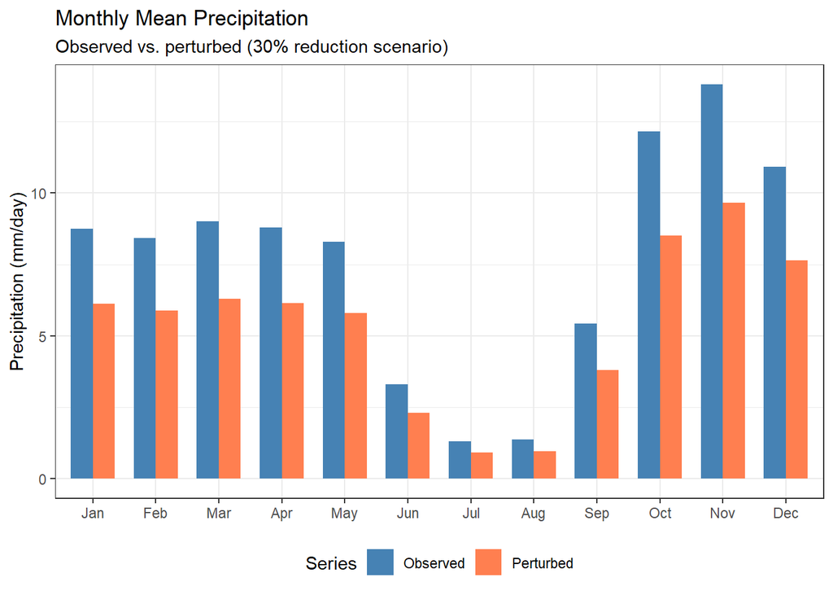

```r
obs_cell <- ncdata$data[[1]]
sim_cell <- rlz_future$data[[1]]

obs_monthly <- tapply(obs_cell$precip, obs_month, mean, na.rm = TRUE)
sim_monthly <- tapply(sim_cell$precip, obs_month, mean, na.rm = TRUE)

plot_data <- data.frame(
  Month = factor(month.abb[1:12], levels = month.abb),
  Observed = as.numeric(obs_monthly),
  Perturbed = as.numeric(sim_monthly)
)
plot_data_long <- tidyr::pivot_longer(
  plot_data, cols = c("Observed", "Perturbed"),
  names_to = "Series", values_to = "Precipitation"
)

ggplot(plot_data_long, aes(x = Month, y = Precipitation, fill = Series)) +
  geom_col(position = "dodge", width = 0.7) +
  scale_fill_manual(values = c(Observed = "steelblue", Perturbed = "coral")) +
  labs(
    title = "Monthly Mean Precipitation",
    subtitle = "Observed vs. perturbed (30% reduction scenario)",
    y = "Precipitation (mm/day)", x = NULL
  ) +
  theme_bw() +
  theme(legend.position = "bottom")
```

### 6.2 Distribution comparison

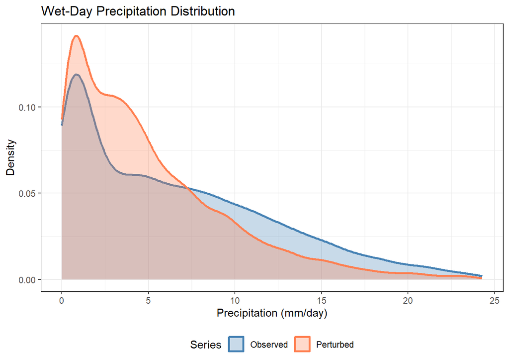

```r
wet_obs <- obs_cell$precip[obs_cell$precip > 0]
wet_sim <- sim_cell$precip[sim_cell$precip > 0]

dist_data <- data.frame(

  Precipitation = c(wet_obs, wet_sim),
  Series = factor(
    c(rep("Observed", length(wet_obs)), rep("Perturbed", length(wet_sim))),
    levels = c("Observed", "Perturbed")
  )
)

ggplot(dist_data, aes(x = Precipitation, color = Series, fill = Series)) +
  geom_density(alpha = 0.3, linewidth = 1) +
  scale_color_manual(values = c(Observed = "steelblue", Perturbed = "coral")) +
  scale_fill_manual(values = c(Observed = "steelblue", Perturbed = "coral")) +
  scale_x_continuous(limits = c(0, quantile(c(wet_obs, wet_sim), 0.98))) +
  labs(
    title = "Wet-Day Precipitation Distribution",
    x = "Precipitation (mm/day)", y = "Density"
  ) +
  theme_bw() +
  theme(legend.position = "bottom")
```

### 6.3 Temperature time series

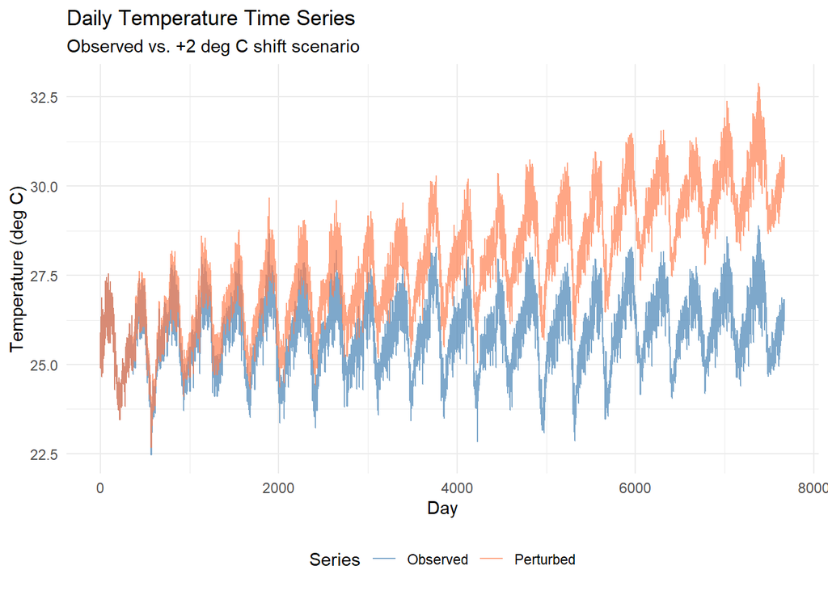

```r
plot_idx <- seq_len(nrow(obs_cell))

temp_ts <- data.frame(
  Day = plot_idx,
  Observed = obs_cell$temp[plot_idx],
  Perturbed = sim_cell$temp[plot_idx]
)
temp_ts_long <- tidyr::pivot_longer(
  temp_ts, cols = c("Observed", "Perturbed"),
  names_to = "Series", values_to = "Temperature"
)

ggplot(temp_ts_long, aes(x = Day, y = Temperature, color = Series)) +
  geom_line(alpha = 0.7) +
  scale_color_manual(values = c(Observed = "steelblue", Perturbed = "coral")) +
  labs(
    title = "Daily Temperature Time Series",
    subtitle = "Observed vs. +2 deg C shift scenario",
    x = "Day", y = "Temperature (deg C)"
  ) +
  theme_minimal() +
  theme(legend.position = "bottom")
```

## 7 Use cases and extensions

### 7.1 Step changes

For immediate perturbations instead of transient ramps:

```r
rlz_step <- apply_climate_perturbations(
  data = ncdata$data, grid = ncdata$grid, date = ncdata$date,
  precip_mean_factor = precip_mean_change,
  precip_var_factor = precip_var_change,
  temp_delta = temp_mean_change,
  temp_transient = FALSE,
  precip_transient = FALSE,
  diagnostic = TRUE
)
```

### 7.2 Occurrence perturbations

To modify wet-day frequency:

```r
occurrence_factor <- rep(1.0, 12)
occurrence_factor[6:8] <- 0.8  # 20% fewer wet days in summer

rlz_dry_summer <- apply_climate_perturbations(
  data = ncdata$data, grid = ncdata$grid, date = ncdata$date,
  precip_mean_factor = precip_mean_change,
  precip_var_factor = precip_var_change,
  precip_occurrence_factor = occurrence_factor,
  temp_delta = temp_mean_change,
  diagnostic = TRUE
)
```

### 7.3 PET recalculation

To propagate temperature changes to PET:

```r
rlz_with_pet <- apply_climate_perturbations(
  data = ncdata$data, grid = ncdata$grid, date = ncdata$date,
  precip_mean_factor = precip_mean_change,
  precip_var_factor = precip_var_change,
  temp_delta = temp_mean_change,
  compute_pet = TRUE,
  pet_method = "hargreaves",
  diagnostic = TRUE
)
```

### 7.4 Extreme amplification

To amplify upper-tail changes:

```r
rlz_extreme <- apply_climate_perturbations(
  data = ncdata$data, grid = ncdata$grid, date = ncdata$date,
  precip_mean_factor = precip_mean_change,
  precip_var_factor = precip_var_change,
  temp_delta = temp_mean_change,
  exaggerate_extremes = TRUE,
  extreme_prob_threshold = 0.95,
  extreme_k = 1.2,
  diagnostic = TRUE
)
```